# Heritability and polygenic scores

Statistical genetics practical in RStudio on Biowulf

## 1 Purpose and preparation

This practical examines SNP heritability, shared genetic effects, functional annotation enrichment, and polygenic scores. The analyses use GCTA/GREML, LD Score regression, genetic correlation, stratified LD Score regression, and clumping and thresholding. R runs the command-line programs and summarizes their results.

Open `04_Heritability_PRS.Rmd` in **Biowulf OnDemand RStudio**. Keep the `R/` and `scripts/` folders beside this file. Use a compute allocation with at least 2 CPUs; 16 GB RAM is a suggested starting request. Runtime and memory use have not yet been measured on the intended allocation. The R packages `data.table`, `knitr`, and `rmarkdown` must be installed before class. The supplied scripts load Biowulf’s GCTA, LDSC, PLINK 1.9, and PLINK 2 modules separately for each command.

Use **Knit** to run the document and generate an HTML report. To run individual chunks, first select **Session > Set Working Directory > To Source File Location** in RStudio, then run the setup chunk and the subsequent chunks in order. You can also render the document from its containing directory:

```r
rmarkdown::render("04_Heritability_PRS.Rmd")
```

The default is to execute every analysis. For a 45–60 minute class, an instructor may assign genetic correlation and stratified LDSC as follow-up exercises or prepare results in advance.

The document parameters control the input path, thread count, sections to run, and output location. Setting `execute = FALSE` makes a **code-only preview**:

```r
rmarkdown::render("04_Heritability_PRS.Rmd",
                  params = list(execute = FALSE),
                  output_file = "04_Heritability_PRS.preview.html")
```

### 1.1 Input files and results directory

The GCTA phenotype file is `phenotype.phen` in the `result` directory beside the shared `data` directory. Leaving `gcta_phenotype` empty selects this file automatically. The paths below identify the input data, phenotype file, and output directory:

```r
data_dir
```

```
## [1] "/vf/users/DCEG_shared/statgen_workshop_2026/data/statgen_workshop_04Heritability_PRS/data"
```

```r
phenotype_path
```

```
## [1] "/vf/users/DCEG_shared/statgen_workshop_2026/data/statgen_workshop_04Heritability_PRS/result/phenotype.phen"
```

```r
run_dir
```

```
## [1] "/vf/users/wongs6/statgen_workshop_2026/heritability-prs/results/run-20260929-133802-38aae1209f79aa"
```

Each execution creates a new results subdirectory. Inputs remain read-only. Command arguments, standard output, standard error, exit status, parameters, input sizes, and the R session information are retained there. A failed command stops rendering rather than displaying an earlier result as a new result.

Readiness of the requested analyses

|  | section | requested | inputs_readable | tools_available | status |
| --- | --- | --- | --- | --- | --- |
| gcta | gcta | TRUE | TRUE | TRUE | ready |
| ldsc | ldsc | TRUE | TRUE | TRUE | ready |
| sldsc | sldsc | TRUE | TRUE | TRUE | ready |
| prs | prs | TRUE | TRUE | TRUE | ready |

If a requested section is unavailable, its code remains visible and it is marked **Not run**. A missing software module is distinct from a missing input; consult `tool-*.stderr.txt` and `input_inventory.csv` in the results directory.

## 2 SNP heritability with GCTA/GREML

The chromosome 22 data were generated from European 1000 Genomes genotypes, with generating heritability 0.2 and 5% causal variants. The supplied files contain 498 individuals and 34,386 variants. The generating value is a simulation setting; the fitted estimate has sampling uncertainty.

This section uses the supplied data and records newly computed results.

### 2.1 Check phenotype identifiers

The phenotype file has three columns without a header: family ID, individual ID, and quantitative phenotype. Both IDs must match the genotype file. The phenotype column in `chr22.fam` contains only the missing-value code `-9` and must not replace this phenotype file.

```r
phenotype_summary <- validate_gcta_phenotype(
  file.path(data_dir, "chr22.fam"), phenotype_path
)
knitr::kable(phenotype_summary)
```

| samples | mean | sd |
| --- | --- | --- |
| 498 | 0.038171 | 0.8895653 |

### 2.2 Estimate the genetic relationship matrix

```r
grm_prefix <- file.path(run_dir, "chr22")
run_command(
  tool_paths[["gcta"]],
  c("--bfile", file.path(data_dir, "chr22"),
    "--make-grm", "--thread-num", as.character(threads), "--out", grm_prefix),
  log_prefix = file.path(run_dir, "gcta_make_grm"),
  expected = paste0(grm_prefix, c(".grm.bin", ".grm.N.bin", ".grm.id"))
)
```

```
## Running gcta_make_grm
```

### 2.3 Estimate the variance components

Apply a relatedness cutoff of 0.05. Inspect the GCTA log for the number of individuals retained after this cutoff.

```r
gcta_prefix <- file.path(run_dir, "gcta_herit")
run_command(
  tool_paths[["gcta"]],
  c("--reml", "--grm", grm_prefix, "--pheno", phenotype_path,
    "--grm-cutoff", "0.05", "--thread-num", as.character(threads),
    "--out", gcta_prefix),
  log_prefix = file.path(run_dir, "gcta_reml"),
  expected = paste0(gcta_prefix, c(".hsq", ".log"))
)
```

```
## Running gcta_reml
```

```r
cat(paste(readLines(paste0(gcta_prefix, ".hsq")), collapse = "\n"))
```

```
## Source   Variance    SE
## V(G) 0.202831    0.396842
## V(e) 0.374109    0.390763
## Vp   0.576940    0.094068
## V(G)/Vp  0.351564    0.679710
## logL -19.077
## logL0    -19.223
## LRT  0.291
## df   1
## Pval 2.9476e-01
## n    77
```

In the `.hsq` output, `V(G)` is the fitted genetic variance, `V(e)` the residual variance, and `V(G)/Vp` their heritability ratio. Read the ratio together with its standard error. Compare it with the generating value of 0.2 and consider the small sample size and restriction to chromosome 22. See the [GCTA documentation](https://yanglab.westlake.edu.cn/software/gcta/).

## 3 LD Score regression for breast cancer

This analysis uses GWAS summary statistics for overall breast cancer (`overall_bc`), luminal A breast cancer (`lua_bc`), and triple-negative breast cancer (`tn_bc`). The study background is described by [Zhang et al. (2020)](https://doi.org/10.1038/s41588-020-0609-2). These analyses use the supplied summary statistics and European LD reference files directly.

The primary software reference is the original authors’ [LDSC repository](https://github.com/bulik/ldsc), with instructions for [heritability and genetic correlation](https://github.com/bulik/ldsc/wiki/Heritability-and-Genetic-Correlation) and [partitioned heritability](https://github.com/bulik/ldsc/wiki/Partitioned-Heritability). The supplied launcher loads the Biowulf LDSC module. A custom installation can instead be selected with the `tool_mode`, `ldsc_dir`, and `ldsc_python` parameters. The authors’ repository also links to the [CBIIT Python 3 implementation](https://github.com/CBIIT/ldsc).

This section uses the supplied data and records newly computed results.

### 3.1 Inspect the supplied summary statistics

| Column | Meaning in the supplied data |
| --- | --- |
| `snpid` | rs identifier when available; otherwise chromosome and position |
| `CHR`, `bp` | Chromosome and GRCh37 position |
| `A1`, `A2` | Effect and non-effect alleles |
| `Z`, `P` | Signed association statistic and P value |
| `info`, `MAF` | Imputation quality and minor allele frequency |
| `N` | Supplied effective sample size, calculated as $1 / [\operatorname{var}(\hat\beta)\,2f(1-f)]$ |

The supplied `N` definition is used to estimate genetic variance on the logit scale. The commands below supply neither population prevalence nor sample prevalence for a liability-scale transformation. Interpret the fitted variance in the context of this `N` definition; do not report it automatically as liability-scale heritability or a proportion of an individual’s disease risk.

Read a few rows for inspection without loading the complete overall breast cancer file into R. LDSC will read the full file in the next step.

```r
bcac_overall <- data.table::fread(
  file.path(data_dir, "overall_bc"), nrows = 6L
)
knitr::kable(bcac_overall)
```

| snpid | CHR | bp | A2 | A1 | Z | P | info | MAF | N |
| --- | --- | --- | --- | --- | --- | --- | --- | --- | --- |
| chr1:11008 | 1 | 11008 | G | C | -1.9783658 | 0.0478875 | 0.579745 | 0.0974118 | 24184.71 |
| chr1:11012 | 1 | 11012 | G | C | -1.9783608 | 0.0478880 | 0.579746 | 0.0974118 | 24184.71 |
| rs201725126 | 1 | 13116 | G | T | 0.7119430 | 0.4765001 | 0.388268 | 0.1751340 | 17920.88 |
| rs200579949 | 1 | 13118 | G | A | 0.7119523 | 0.4764943 | 0.388268 | 0.1751340 | 17920.88 |
| chr1:13273 | 1 | 13273 | C | G | 0.8408968 | 0.4004058 | 0.356340 | 0.1435200 | 17208.96 |
| chr1:14464 | 1 | 14464 | T | A | -0.6623217 | 0.5077651 | 0.346048 | 0.1634150 | 16821.18 |

### 3.2 Prepare overall breast cancer summary statistics

Require imputation quality of at least 0.3 and minor allele frequency of at least 0.01. Alleles are matched against the supplied HapMap3 SNP list. Examine the munging log to see how many variants remain after each filter.

```r
munge_overall_prefix <- file.path(run_dir, "ldsc_herit_overall")
munge_result <- paste0(munge_overall_prefix, ".sumstats.gz")

run_ldsc(
  "munge_sumstats.py",
  c(
    "--sumstats", file.path(data_dir, "overall_bc"),
    "--out", munge_overall_prefix,
    "--merge-alleles", file.path(data_dir, "eur_w_ld_chr", "w_hm3.snplist"),
    "--chunksize", "500000",
    "--signed-sumstats", "Z,0",
    "--info-min", "0.3",
    "--maf-min", "0.01"
  ),
  label = "munge_overall",
  expected = c(munge_result, paste0(munge_overall_prefix, ".log"))
)
```

```
## Running munge_overall
```

```r
read_ldsc_log(munge_overall_prefix)
```

```
## * LD Score Regression (LDSC)
## * Version 1.0.1
## * (C) 2014-2019 Brendan Bulik-Sullivan and Hilary Finucane
## * Broad Institute of MIT and Harvard / MIT Department of Mathematics
## * GNU General Public License v3
## Call:
## ./munge_sumstats.py \
## --signed-sumstats Z,0 \
## --out /vf/users/wongs6/statgen_workshop_2026/heritability-prs/results/run-20260929-133802-38aae1209f79aa/ldsc_herit_overall \
## --merge-alleles /vf/users/DCEG_shared/statgen_workshop_2026/data/statgen_workshop_04Heritability_PRS/data/eur_w_ld_chr/w_hm3.snplist \
## --info-min 0.3 \
## --chunksize 500000 \
## --sumstats /vf/users/DCEG_shared/statgen_workshop_2026/data/statgen_workshop_04Heritability_PRS/data/overall_bc
##
## Interpreting column names as follows:
## info:    INFO score (imputation quality; higher --> better imputation)
## snpid:   Variant ID (e.g., rs number)
## N:   Sample size
## A1:  Allele 1, interpreted as ref allele for signed sumstat.
## P:   p-Value
## A2:  Allele 2, interpreted as non-ref allele for signed sumstat.
## MAF: Allele frequency
## Z:   Directional summary statistic as specified by --signed-sumstats.
##
## Reading list of SNPs for allele merge from /vf/users/DCEG_shared/statgen_workshop_2026/data/statgen_workshop_04Heritability_PRS/data/eur_w_ld_chr/w_hm3.snplist
## Read 1217311 SNPs for allele merge.
## Reading sumstats from /vf/users/DCEG_shared/statgen_workshop_2026/data/statgen_workshop_04Heritability_PRS/data/overall_bc into memory 500000 SNPs at a time.
## WARNING: 3 SNPs had P outside of (0,1]. The P column may be mislabeled.
## Read 10760767 SNPs from --sumstats file.
## Removed 9646742 SNPs not in --merge-alleles.
## Removed 0 SNPs with missing values.
## Removed 0 SNPs with INFO <= 0.3.
## Removed 9003 SNPs with MAF <= 0.01.
## Removed 3 SNPs with out-of-bounds p-values.
## Removed 344 variants that were not SNPs or were strand-ambiguous.
## 1104675 SNPs remain.
## Removed 319 SNPs with duplicated rs numbers (1104356 SNPs remain).
## Removed 17737 SNPs with N < 33553.1203979 (1086619 SNPs remain).
## Median value of SIGNED_SUMSTATS was -0.00206242490166, which seems sensible.
## Removed 137 SNPs whose alleles did not match --merge-alleles (1086482 SNPs remain).
## Writing summary statistics for 1217311 SNPs (1086482 with nonmissing beta) to /vf/users/wongs6/statgen_workshop_2026/heritability-prs/results/run-20260929-133802-38aae1209f79aa/ldsc_herit_overall.sumstats.gz.
##
## Metadata:
## Mean chi^2 = 1.521
## Lambda GC = 1.304
## Max chi^2 = 1399.129
## 1571 Genome-wide significant SNPs (some may have been removed by filtering).
##
## Conversion finished at Tue Sep 29 13:38:47 2026
## Total time elapsed: 33.71s
```

### 3.3 Estimate the overall breast cancer genetic variance

The same chromosome-specific European LD scores are used for the reference and regression weights. The trailing slash is required because LDSC appends chromosome numbers to this prefix.

```r
eur_ld_prefix <- paste0(file.path(data_dir, "eur_w_ld_chr"), "/")
h2_overall_prefix <- file.path(run_dir, "h2_overall")

run_ldsc(
  "ldsc.py",
  c(
    "--h2", munge_result,
    "--ref-ld-chr", eur_ld_prefix,
    "--w-ld-chr", eur_ld_prefix,
    "--out", h2_overall_prefix
  ),
  label = "estimate_overall_h2",
  expected = paste0(h2_overall_prefix, ".log")
)
```

```
## Running estimate_overall_h2
```

```r
read_ldsc_log(h2_overall_prefix)
```

```
## * LD Score Regression (LDSC)
## * Version 1.0.1
## * (C) 2014-2019 Brendan Bulik-Sullivan and Hilary Finucane
## * Broad Institute of MIT and Harvard / MIT Department of Mathematics
## * GNU General Public License v3
## Call:
## ./ldsc.py \
## --h2 /vf/users/wongs6/statgen_workshop_2026/heritability-prs/results/run-20260929-133802-38aae1209f79aa/ldsc_herit_overall.sumstats.gz \
## --ref-ld-chr /vf/users/DCEG_shared/statgen_workshop_2026/data/statgen_workshop_04Heritability_PRS/data/eur_w_ld_chr/ \
## --out /vf/users/wongs6/statgen_workshop_2026/heritability-prs/results/run-20260929-133802-38aae1209f79aa/h2_overall \
## --w-ld-chr /vf/users/DCEG_shared/statgen_workshop_2026/data/statgen_workshop_04Heritability_PRS/data/eur_w_ld_chr/
##
## Beginning analysis at Tue Sep 29 13:38:50 2026
## Reading summary statistics from /vf/users/wongs6/statgen_workshop_2026/heritability-prs/results/run-20260929-133802-38aae1209f79aa/ldsc_herit_overall.sumstats.gz ...
## Read summary statistics for 1086482 SNPs.
## Reading reference panel LD Score from /vf/users/DCEG_shared/statgen_workshop_2026/data/statgen_workshop_04Heritability_PRS/data/eur_w_ld_chr/[1-22] ... (ldscore_fromlist)
## Read reference panel LD Scores for 1290028 SNPs.
## Removing partitioned LD Scores with zero variance.
## Reading regression weight LD Score from /vf/users/DCEG_shared/statgen_workshop_2026/data/statgen_workshop_04Heritability_PRS/data/eur_w_ld_chr/[1-22] ... (ldscore_fromlist)
## Read regression weight LD Scores for 1290028 SNPs.
## After merging with reference panel LD, 1079667 SNPs remain.
## After merging with regression SNP LD, 1079667 SNPs remain.
## Using two-step estimator with cutoff at 30.
## Total Observed scale h2: 0.4777 (0.0374)
## Lambda GC: 1.3034
## Mean Chi^2: 1.5205
## Intercept: 1.0863 (0.0122)
## Ratio: 0.1657 (0.0235)
## Analysis finished at Tue Sep 29 13:38:57 2026
## Total time elapsed: 6.41s
```

Read the estimate together with its standard error, the mean chi-square statistic, and the intercept. Record the scale implied by the supplied sample size definition.

### 3.4 Estimate the genetic correlation between subtypes

Prepare luminal A and triple-negative breast cancer summary statistics with the same filters used for overall breast cancer.

```r
lua <- data.table::fread(file.path(data_dir, "lua_bc"), nrows = 6L)
tn <- data.table::fread(file.path(data_dir, "tn_bc"), nrows = 6L)
knitr::kable(lua, caption = "Luminal A summary statistics")
```

Luminal A summary statistics

| snpid | CHR | bp | A2 | A1 | Z | P | info | MAF | N |
| --- | --- | --- | --- | --- | --- | --- | --- | --- | --- |
| rs12298882 | 12 | 1993258 | T | C | 0.0986324 | 0.9214302 | 1 | 0.176 | 24867.45 |
| rs10770543 | 12 | 19933269 | C | T | 0.8469411 | 0.3970280 | 1 | 0.162 | 25034.35 |
| rs10841354 | 12 | 19939907 | A | G | 1.9015651 | 0.0572280 | 1 | 0.451 | 30661.01 |
| rs2731629 | 12 | 19944345 | A | G | -0.2014745 | 0.8403276 | 1 | 0.134 | 28083.89 |
| rs11044855 | 12 | 19944551 | A | G | 1.8280939 | 0.0675355 | 1 | 0.441 | 30573.49 |
| rs10841363 | 12 | 19947813 | A | C | 0.2199160 | 0.8259366 | 1 | 0.194 | 29797.58 |

```r
knitr::kable(tn, caption = "Triple-negative summary statistics")
```

Triple-negative summary statistics

| snpid | CHR | bp | A2 | A1 | Z | P | info | MAF | N |
| --- | --- | --- | --- | --- | --- | --- | --- | --- | --- |
| rs12298882 | 12 | 1993258 | T | C | -0.8375361 | 0.4022913 | 1 | 0.176 | 6710.899 |
| rs10770543 | 12 | 19933269 | C | T | -0.5852488 | 0.5583804 | 1 | 0.162 | 6905.901 |
| rs10841354 | 12 | 19939907 | A | G | 0.6252989 | 0.5317749 | 1 | 0.451 | 8351.929 |
| rs2731629 | 12 | 19944345 | A | G | -0.8628318 | 0.3882299 | 1 | 0.134 | 7491.037 |
| rs11044855 | 12 | 19944551 | A | G | 0.2905657 | 0.7713835 | 1 | 0.441 | 8315.522 |
| rs10841363 | 12 | 19947813 | A | C | 0.7584617 | 0.4481746 | 1 | 0.194 | 8266.724 |

```r
subtype_inputs <- c(lua = "lua_bc", tn = "tn_bc")
for (subtype in names(subtype_inputs)) {
  subtype_prefix <- file.path(run_dir, paste0("ldsc_herit_", subtype))
  run_ldsc(
    "munge_sumstats.py",
    c(
      "--sumstats", file.path(data_dir, subtype_inputs[[subtype]]),
      "--out", subtype_prefix,
      "--merge-alleles", file.path(data_dir, "eur_w_ld_chr", "w_hm3.snplist"),
      "--chunksize", "500000",
      "--signed-sumstats", "Z,0",
      "--info-min", "0.3",
      "--maf-min", "0.01"
    ),
    label = paste0("munge_", subtype),
    expected = paste0(subtype_prefix, c(".sumstats.gz", ".log"))
  )
  read_ldsc_log(subtype_prefix)
}
```

```
## Running munge_lua
## * LD Score Regression (LDSC)
## * Version 1.0.1
## * (C) 2014-2019 Brendan Bulik-Sullivan and Hilary Finucane
## * Broad Institute of MIT and Harvard / MIT Department of Mathematics
## * GNU General Public License v3
## Call:
## ./munge_sumstats.py \
## --signed-sumstats Z,0 \
## --out /vf/users/wongs6/statgen_workshop_2026/heritability-prs/results/run-20260929-133802-38aae1209f79aa/ldsc_herit_lua \
## --merge-alleles /vf/users/DCEG_shared/statgen_workshop_2026/data/statgen_workshop_04Heritability_PRS/data/eur_w_ld_chr/w_hm3.snplist \
## --info-min 0.3 \
## --chunksize 500000 \
## --sumstats /vf/users/DCEG_shared/statgen_workshop_2026/data/statgen_workshop_04Heritability_PRS/data/lua_bc
##
## Interpreting column names as follows:
## info:    INFO score (imputation quality; higher --> better imputation)
## snpid:   Variant ID (e.g., rs number)
## N:   Sample size
## A1:  Allele 1, interpreted as ref allele for signed sumstat.
## P:   p-Value
## A2:  Allele 2, interpreted as non-ref allele for signed sumstat.
## MAF: Allele frequency
## Z:   Directional summary statistic as specified by --signed-sumstats.
##
## Reading list of SNPs for allele merge from /vf/users/DCEG_shared/statgen_workshop_2026/data/statgen_workshop_04Heritability_PRS/data/eur_w_ld_chr/w_hm3.snplist
## Read 1217311 SNPs for allele merge.
## Reading sumstats from /vf/users/DCEG_shared/statgen_workshop_2026/data/statgen_workshop_04Heritability_PRS/data/lua_bc into memory 500000 SNPs at a time.
## WARNING: 3 SNPs had P outside of (0,1]. The P column may be mislabeled.
## Read 1173631 SNPs from --sumstats file.
## Removed 0 SNPs not in --merge-alleles.
## Removed 16596 SNPs with missing values.
## Removed 0 SNPs with INFO <= 0.3.
## Removed 967 SNPs with MAF <= 0.01.
## Removed 3 SNPs with out-of-bounds p-values.
## Removed 10 variants that were not SNPs or were strand-ambiguous.
## 1156055 SNPs remain.
## Removed 11 SNPs with duplicated rs numbers (1156044 SNPs remain).
## Removed 46337 SNPs with N < 21719.7960918 (1109707 SNPs remain).
## Median value of SIGNED_SUMSTATS was -0.00136583037108, which seems sensible.
```

[output cut: 46 more lines]

```
## 1156058 SNPs remain.
## Removed 11 SNPs with duplicated rs numbers (1156047 SNPs remain).
## Removed 43766 SNPs with N < 5897.08919163 (1112281 SNPs remain).
## Median value of SIGNED_SUMSTATS was 0.00592960612155, which seems sensible.
## Removed 1 SNPs whose alleles did not match --merge-alleles (1112280 SNPs remain).
## Writing summary statistics for 1217311 SNPs (1112280 with nonmissing beta) to /vf/users/wongs6/statgen_workshop_2026/heritability-prs/results/run-20260929-133802-38aae1209f79aa/ldsc_herit_tn.sumstats.gz.
##
## Metadata:
## Mean chi^2 = 1.117
## Lambda GC = 1.089
## Max chi^2 = 212.793
## 241 Genome-wide significant SNPs (some may have been removed by filtering).
##
## Conversion finished at Tue Sep 29 13:39:37 2026
## Total time elapsed: 15.77s
```

```r
munge_result_lua <- file.path(run_dir, "ldsc_herit_lua.sumstats.gz")
munge_result_tn <- file.path(run_dir, "ldsc_herit_tn.sumstats.gz")
```

```r
rg_prefix <- file.path(run_dir, "rg_lua_tn")
run_ldsc(
  "ldsc.py",
  c(
    "--rg", paste(munge_result_lua, munge_result_tn, sep = ","),
    "--ref-ld-chr", eur_ld_prefix,
    "--w-ld-chr", eur_ld_prefix,
    "--out", rg_prefix
  ),
  label = "estimate_genetic_correlation",
  expected = paste0(rg_prefix, ".log")
)
```

```
## Running estimate_genetic_correlation
```

```r
read_ldsc_log(rg_prefix)
```

```
## * LD Score Regression (LDSC)
## * Version 1.0.1
## * (C) 2014-2019 Brendan Bulik-Sullivan and Hilary Finucane
## * Broad Institute of MIT and Harvard / MIT Department of Mathematics
## * GNU General Public License v3
## Call:
## ./ldsc.py \
## --ref-ld-chr /vf/users/DCEG_shared/statgen_workshop_2026/data/statgen_workshop_04Heritability_PRS/data/eur_w_ld_chr/ \
## --out /vf/users/wongs6/statgen_workshop_2026/heritability-prs/results/run-20260929-133802-38aae1209f79aa/rg_lua_tn \
## --rg /vf/users/wongs6/statgen_workshop_2026/heritability-prs/results/run-20260929-133802-38aae1209f79aa/ldsc_herit_lua.sumstats.gz,/vf/users/wongs6/statgen_workshop_2026/heritability-prs/results/run-20260929-133802-38aae1209f79aa/ldsc_herit_tn.sumstats.gz \
## --w-ld-chr /vf/users/DCEG_shared/statgen_workshop_2026/data/statgen_workshop_04Heritability_PRS/data/eur_w_ld_chr/
##
## Beginning analysis at Tue Sep 29 13:39:41 2026
## Reading summary statistics from /vf/users/wongs6/statgen_workshop_2026/heritability-prs/results/run-20260929-133802-38aae1209f79aa/ldsc_herit_lua.sumstats.gz ...
## Read summary statistics for 1109706 SNPs.
## Reading reference panel LD Score from /vf/users/DCEG_shared/statgen_workshop_2026/data/statgen_workshop_04Heritability_PRS/data/eur_w_ld_chr/[1-22] ... (ldscore_fromlist)
## Read reference panel LD Scores for 1290028 SNPs.
## Removing partitioned LD Scores with zero variance.
## Reading regression weight LD Score from /vf/users/DCEG_shared/statgen_workshop_2026/data/statgen_workshop_04Heritability_PRS/data/eur_w_ld_chr/[1-22] ... (ldscore_fromlist)
## Read regression weight LD Scores for 1290028 SNPs.
## After merging with reference panel LD, 1104512 SNPs remain.
## After merging with regression SNP LD, 1104512 SNPs remain.
## Computing rg for phenotype 2/2
## Reading summary statistics from /vf/users/wongs6/statgen_workshop_2026/heritability-prs/results/run-20260929-133802-38aae1209f79aa/ldsc_herit_tn.sumstats.gz ...
## Read summary statistics for 1217311 SNPs.
## After merging with summary statistics, 1104512 SNPs remain.
## 1102200 SNPs with valid alleles.
##
## Heritability of phenotype 1
## ---------------------------
## Total Observed scale h2: 0.7522 (0.0762)
## Lambda GC: 1.2932
## Mean Chi^2: 1.5593
## Intercept: 1.1164 (0.0226)
## Ratio: 0.2081 (0.0405)
##
## Heritability of phenotype 2/2
## -----------------------------
## Total Observed scale h2: 0.5972 (0.0788)
## Lambda GC: 1.0864
```

[output cut: 8 more lines]

```
## Intercept: 0.2136 (0.0075)
##
## Genetic Correlation
## -------------------
## Genetic Correlation: 0.4829 (0.0512)
## Z-score: 9.4264
## P: 4.2421e-21
##
##
## Summary of Genetic Correlation Results
## p1                                                                                                                            p2      rg      se       z           p  h2_obs  h2_obs_se  h2_int  h2_int_se  gcov_int  gcov_int_se
## /vf/users/wongs6/statgen_workshop_2026/heritability-prs/results/run-20260929-133802-38aae1209f79aa/ldsc_herit_lua.sumstats.gz  /vf/users/wongs6/statgen_workshop_2026/heritability-prs/results/run-20260929-133802-38aae1209f79aa/ldsc_herit_tn.sumstats.gz  0.4829  0.0512  9.4264  4.2421e-21  0.5972  …
##
## Analysis finished at Tue Sep 29 13:39:50 2026
## Total time elapsed: 9.49s
```

Report the genetic correlation with its standard error. Discuss whether the estimate suggests shared common-variant effects between the two subtypes. Genetic correlation alone does not establish a causal relationship.

## 4 Stratified LD Score regression

Stratified LD Score regression estimates how genetic variance is distributed across functional annotations. This analysis uses the baseline-LD model with overlapping annotations, the supplied allele-frequency files and regression weights, and the overall breast cancer summary statistics prepared above.

This section uses the supplied data and records newly computed results.

```r
sldsc_prefix <- file.path(run_dir, "h2_sldsc")
run_ldsc(
  "ldsc.py",
  c(
    "--h2", file.path(run_dir, "ldsc_herit_overall.sumstats.gz"),
    "--ref-ld-chr", file.path(
      data_dir, "1000G_Phase3_baselineLD_ldscores", "baselineLD."
    ),
    "--w-ld-chr", file.path(
      data_dir, "1000G_Phase3_weights_hm3_no_MHC", "weights.hm3_noMHC."
    ),
    "--overlap-annot",
    "--frqfile-chr", file.path(
      data_dir, "1000G_Phase3_frq", "1000G.EUR.QC."
    ),
    "--out", sldsc_prefix
  ),
  label = "estimate_stratified_h2",
  expected = paste0(sldsc_prefix, c(".results", ".log"))
)
```

```
## Running estimate_stratified_h2
```

```r
read_ldsc_log(sldsc_prefix)
```

```
## * LD Score Regression (LDSC)
## * Version 1.0.1
## * (C) 2014-2019 Brendan Bulik-Sullivan and Hilary Finucane
## * Broad Institute of MIT and Harvard / MIT Department of Mathematics
## * GNU General Public License v3
## Call:
## ./ldsc.py \
## --h2 /vf/users/wongs6/statgen_workshop_2026/heritability-prs/results/run-20260929-133802-38aae1209f79aa/ldsc_herit_overall.sumstats.gz \
## --ref-ld-chr /vf/users/DCEG_shared/statgen_workshop_2026/data/statgen_workshop_04Heritability_PRS/data/1000G_Phase3_baselineLD_ldscores/baselineLD. \
## --out /vf/users/wongs6/statgen_workshop_2026/heritability-prs/results/run-20260929-133802-38aae1209f79aa/h2_sldsc \
## --overlap-annot  \
## --frqfile-chr /vf/users/DCEG_shared/statgen_workshop_2026/data/statgen_workshop_04Heritability_PRS/data/1000G_Phase3_frq/1000G.EUR.QC. \
## --w-ld-chr /vf/users/DCEG_shared/statgen_workshop_2026/data/statgen_workshop_04Heritability_PRS/data/1000G_Phase3_weights_hm3_no_MHC/weights.hm3_noMHC.
##
## Beginning analysis at Tue Sep 29 13:39:53 2026
## Reading summary statistics from /vf/users/wongs6/statgen_workshop_2026/heritability-prs/results/run-20260929-133802-38aae1209f79aa/ldsc_herit_overall.sumstats.gz ...
## Read summary statistics for 1086482 SNPs.
## Reading reference panel LD Score from /vf/users/DCEG_shared/statgen_workshop_2026/data/statgen_workshop_04Heritability_PRS/data/1000G_Phase3_baselineLD_ldscores/baselineLD.[1-22] ... (ldscore_fromlist)
## Read reference panel LD Scores for 1190321 SNPs.
## Removing partitioned LD Scores with zero variance.
## Reading regression weight LD Score from /vf/users/DCEG_shared/statgen_workshop_2026/data/statgen_workshop_04Heritability_PRS/data/1000G_Phase3_weights_hm3_no_MHC/weights.hm3_noMHC.[1-22] ... (ldscore_fromlist)
## Read regression weight LD Scores for 1187349 SNPs.
## After merging with reference panel LD, 1078672 SNPs remain.
## After merging with regression SNP LD, 1075920 SNPs remain.
## Removed 79 SNPs with chi^2 > 186.494625 (1075841 SNPs remain)
## Total Observed scale h2: 0.5198 (0.0334)
## Categories: baseL2_0 Coding_UCSCL2_0 Coding_UCSC.extend.500L2_0 Conserved_LindbladTohL2_0 Conserved_LindbladToh.extend.500L2_0 CTCF_HoffmanL2_0 CTCF_Hoffman.extend.500L2_0 DGF_ENCODEL2_0 DGF_ENCODE.extend.500L2_0 DHS_peaks_TrynkaL2_0 DHS_TrynkaL2_0 DHS_Trynka.extend.500L2_0 Enhancer_AnderssonL2_0…
## Lambda GC: 1.3034
## Mean Chi^2: 1.4938
## Intercept: 1.0591 (0.0144)
## Ratio: 0.1197 (0.0292)
## Reading annot matrix from /vf/users/DCEG_shared/statgen_workshop_2026/data/statgen_workshop_04Heritability_PRS/data/1000G_Phase3_baselineLD_ldscores/baselineLD.[1-22] ... (annot)
## Results printed to /vf/users/wongs6/statgen_workshop_2026/heritability-prs/results/run-20260929-133802-38aae1209f79aa/h2_sldsc.results
## Analysis finished at Tue Sep 29 13:41:13 2026
## Total time elapsed: 1.0m:20.76s
```

### 4.1 Inspect annotation enrichment and its uncertainty

For a binary annotation, enrichment compares its estimated proportion of genetic variance with its proportion of SNPs. The largest point estimate may also have substantial uncertainty. Inspect its standard error and P value before drawing a conclusion; the maximum is selected after comparing several annotations.

```r
enrichment_result <- data.table::fread(paste0(sldsc_prefix, ".results"))
required_enrichment_columns <- c(
  "Category", "Prop._SNPs", "Prop._h2", "Prop._h2_std_error",
  "Enrichment", "Enrichment_std_error", "Enrichment_p"
)
stopifnot(all(required_enrichment_columns %in% names(enrichment_result)))
knitr::kable(head(enrichment_result))
```

| Category | Prop._SNPs | Prop._h2 | Prop._h2_std_error | Enrichment | Enrichment_std_error | Enrichment_p |
| --- | --- | --- | --- | --- | --- | --- |
| baseL2_0 | 1.0000000 | 1.0000000 | 0.0000000 | 1.0000000 | 0.0000000 | NA |
| Coding_UCSCL2_0 | 0.0142749 | 0.0377794 | 0.0407621 | 2.6465581 | 2.8555099 | 0.5637722 |
| Coding_UCSC.extend.500L2_0 | 0.0636618 | 0.0899979 | 0.0374902 | 1.4136880 | 0.5888965 | 0.4808129 |
| Conserved_LindbladTohL2_0 | 0.0256851 | 0.1826082 | 0.0645421 | 7.1094988 | 2.5128227 | 0.0191075 |
| Conserved_LindbladToh.extend.500L2_0 | 0.3304124 | 0.5747034 | 0.0877462 | 1.7393516 | 0.2655656 | 0.0064157 |
| CTCF_HoffmanL2_0 | 0.0238662 | 0.0165424 | 0.0554234 | 0.6931309 | 2.3222583 | 0.8945373 |

```r
finite_enrichment <- which(is.finite(enrichment_result$Enrichment))
if (length(finite_enrichment) == 0L) {
  stop("The stratified LDSC results contain no finite enrichment estimates.")
}
max_enrichment_row <- finite_enrichment[
  which.max(enrichment_result$Enrichment[finite_enrichment])
]
knitr::kable(
  enrichment_result[max_enrichment_row],
  caption = "Annotation with the largest observed enrichment estimate"
)
```

Annotation with the largest observed enrichment estimate

| Category | Prop._SNPs | Prop._h2 | Prop._h2_std_error | Enrichment | Enrichment_std_error | Enrichment_p |
| --- | --- | --- | --- | --- | --- | --- |
| Enhancer_AnderssonL2_0 | 0.0043277 | 0.0414531 | 0.036802 | 9.578583 | 8.503865 | 0.3128075 |

Examine the Andersson enhancer annotation in more detail. Select it by name to identify the same annotation regardless of the results table’s row order.

```r
andersson_result <- enrichment_result[
  enrichment_result$Category == "Enhancer_AnderssonL2_0"
]
if (nrow(andersson_result) != 1L) {
  stop(
    "Expected one Enhancer_AnderssonL2_0 result. ",
    "Check the baseline annotation version and Category column."
  )
}
knitr::kable(andersson_result, caption = "Andersson enhancer annotation")
```

Andersson enhancer annotation

| Category | Prop._SNPs | Prop._h2 | Prop._h2_std_error | Enrichment | Enrichment_std_error | Enrichment_p |
| --- | --- | --- | --- | --- | --- | --- |
| Enhancer_AnderssonL2_0 | 0.0043277 | 0.0414531 | 0.036802 | 9.578583 | 8.503865 | 0.3128075 |

Compare the enhancer estimate with its uncertainty. An enrichment estimate above one is not, by itself, evidence of statistically significant enrichment. Interpret the overlapping annotations jointly rather than adding their estimated proportions.

## 5 Polygenic scores by clumping and thresholding

This exercise uses simulated chromosome 22 data, generated using 1000 Genomes European reference data. `EUR_sum_data` provides association statistics, `1kg_eur_22/chr_22` is the LD reference, and `prs_genotype/chr22_test` contains the target genotypes. The target outcome is `y_out`. These inputs are separate from the breast cancer summary statistics used above.

We use PLINK 1.9 for clumping, PLINK 2 for scoring, and R for outcome regression. We compare nine P-value thresholds and match sample IDs explicitly before analysis.

This section uses the supplied data and records newly computed results.

### 5.1 Check the association statistics and target sample IDs

Use the first 10,000 rows of `y_out` as tuning samples and the next 10,000 rows as validation samples. Record this partition in `prs_sample_partition.tsv`. Scores are matched to these samples by ID, so reordering a score file does not change the partition.

```r
sum_data_file <- file.path(data_dir, "EUR_sum_data")
reference_prefix <- file.path(data_dir, "1kg_eur_22", "chr_22")
target_prefix <- file.path(data_dir, "prs_genotype", "chr22_test")

eur_sum <- fread(sum_data_file, colClasses = c(SNP = "character", A1 = "character"))
prs_require_columns(eur_sum, c("SNP", "A1", "BETA", "P"), "EUR_sum_data")
prs_check_ids(eur_sum$SNP, "EUR_sum_data SNP")
eur_sum[, BETA := prs_as_numeric(BETA, "EUR_sum_data BETA")]
eur_sum[, P := prs_as_numeric(P, "EUR_sum_data P")]
if (any(eur_sum$P < 0 | eur_sum$P > 1)) {
  stop("EUR_sum_data contains P-values outside [0, 1].")
}
if (anyNA(eur_sum$A1) || any(!nzchar(eur_sum$A1))) {
  stop("EUR_sum_data contains a missing effect allele.")
}
if ("TEST" %in% names(eur_sum) && any(is.na(eur_sum$TEST) | eur_sum$TEST != "ADD")) {
  stop("This exercise expects one additive association result per variant.")
}

target_fam <- prs_read_fam(paste0(target_prefix, ".fam"))
target_bim <- prs_read_bim(paste0(target_prefix, ".bim"))
outcome <- prs_read_outcomes(file.path(data_dir, "y_out"), target_fam)
fwrite(outcome[, .(ID, original_row, subset)],
       file.path(run_dir, "prs_sample_partition.tsv"), sep = "\t")
knitr::kable(outcome[, .(samples = .N), by = subset])
```

| subset | samples |
| --- | --- |
| tuning | 10000 |
| validation | 10000 |

```r
head(eur_sum)
```

```
##      CHR                      SNP       BP     A1   TEST  NMISS      BETA
##    <int>                   <char>    <int> <char> <char>  <int>     <num>
## 1:    22          22:16050840:C:G 16050840      G    ADD 100000  0.017800
## 2:    22  rs62224609:16051249:T:C 16051249      C    ADD 100000  0.008931
## 3:    22   rs4965031:16052080:G:A 16052080      A    ADD 100000  0.007013
## 4:    22          22:16052463:T:C 16052463      C    ADD 100000 -0.018200
## 5:    22 rs139918843:16052684:A:C 16052684      C    ADD 100000  0.011530
## 6:    22 rs376238049:16052962:C:T 16052962      T    ADD 100000  0.008499
##       STAT      P
##      <num>  <num>
## 1:  1.1200 0.2626
## 2:  1.1600 0.2461
## 3:  1.0200 0.3078
## 4: -1.2980 0.1942
## 5:  0.6188 0.5361
## 6:  1.0150 0.3103
```

### 5.2 Select index variants using the LD reference

The clumping radius is 500 kb, the LD threshold is $r^2 = 0.1$, and candidate index variants may have P-values up to 1. See the [PLINK clumping documentation](https://www.cog-genomics.org/plink/1.9/postproc#clump) for the interpretation of these parameters.

```r
clump_prefix <- file.path(run_dir, "LD_clump")
run_command(
  tool_paths[["plink"]],
  c("--bfile", reference_prefix,
    "--clump", sum_data_file,
    "--clump-p1", "1", "--clump-r2", "0.1", "--clump-kb", "500",
    "--threads", as.character(threads),
    "--memory", as.character(plink_memory_mb), "--out", clump_prefix),
  log_prefix = paste0(clump_prefix, "_command"),
  expected = paste0(clump_prefix, ".clumped")
)
```

```
## Running LD_clump_command
```

```r
ld_clump <- fread(paste0(clump_prefix, ".clumped"),
                  colClasses = c(SNP = "character"))
prs_require_columns(ld_clump, "SNP", "PLINK clump output")
prs_check_ids(ld_clump$SNP, "Clumped SNP")
if (!all(ld_clump$SNP %in% eur_sum$SNP)) {
  stop("A clumped index variant has no matching association statistic.")
}
prs_prep <- eur_sum[match(ld_clump$SNP, eur_sum$SNP), .(SNP, A1, BETA, P)]
setorder(prs_prep, P, SNP)
head(prs_prep)
```

```
##                         SNP     A1     BETA         P
##                      <char> <char>    <num>     <num>
## 1:   rs5761190:26189870:G:T      G -0.03959 1.416e-15
## 2: rs149657410:47598718:G:A      A  0.13830 5.108e-14
## 3:    rs738697:49026230:T:C      C  0.03544 2.895e-12
## 4:   rs7284488:40412551:G:C      G -0.02799 7.381e-10
## 5:   rs5752361:27027214:C:G      G -0.03996 2.810e-09
## 6:     rs93108:32463610:G:A      G  0.02631 8.425e-09
```

### 5.3 Calculate a score at each P-value threshold

Each score sums effect-allele dosage multiplied by its estimated coefficient. With the `no-mean-imputation` option, missing genotypes do not receive a mean dosage contribution. The requested output column, `SCORE1_SUM`, contains the score sum. See the [PLINK 2 scoring documentation](https://www.cog-genomics.org/plink/2.0/score).

The table records both selected index variants and variants present in the target genotypes. PLINK skips absent variants; an allele mismatch is an error requiring investigation. A threshold with no available variants or a constant tuning score cannot be fitted and is excluded from threshold selection.

```r
p_thresholds <- c(5e-8, 5e-7, 5e-6, 5e-5, 5e-4, 5e-3, 5e-2, 0.5, 1)
tuning_results <- data.table(
  threshold_index = seq_along(p_thresholds),
  p_threshold = p_thresholds,
  selected_variants = 0L,
  target_variants = 0L,
  tuning_r_squared = NA_real_,
  status = "not calculated"
)

for (k in seq_along(p_thresholds)) {
  coefficients <- prs_prep[P <= p_thresholds[k], .(SNP, A1, BETA)]
  tuning_results[k, selected_variants := nrow(coefficients)]
  target_index <- match(coefficients$SNP, target_bim$SNP)
  present <- !is.na(target_index)
  tuning_results[k, target_variants := sum(present)]

  if (!any(present)) {
    tuning_results[k, status := "no selected variants in target genotypes"]
    next
  }
  reference_allele <- coefficients$A1[present]
  target_alleles <- target_bim[target_index[present]]
  if (any(reference_allele != target_alleles$A1 &
          reference_allele != target_alleles$A2)) {
    stop("An effect allele does not match either target allele at threshold ",
         p_thresholds[k], ". Check allele coding before scoring.")
  }

  coefficient_file <- file.path(run_dir, paste0("prs_coeff_", k, ".tsv"))
  score_prefix <- file.path(run_dir, paste0("prs_", k))
  fwrite(coefficients, coefficient_file, sep = "\t", quote = FALSE)
  run_command(
    tool_paths[["plink2"]],
    c("--bfile", target_prefix,
      "--score", coefficient_file, "1", "2", "3", "header",
      "no-mean-imputation", "cols=+scoresums,-scoreavgs",
      "--threads", as.character(threads),
    "--memory", as.character(plink_memory_mb), "--out", score_prefix),
    log_prefix = paste0(score_prefix, "_command"),
    expected = paste0(score_prefix, ".sscore")
  )

  aligned_scores <- prs_align_scores(paste0(score_prefix, ".sscore"),
                                     outcome, target_fam)
  tuning <- aligned_scores[subset == "tuning"]
  if (var(tuning$score) == 0) {
    tuning_results[k, status := "constant tuning score"]
    next
  }
  tuning_model <- lm(y ~ score, data = tuning)
  tuning_results[k, `:=`(
    tuning_r_squared = summary(tuning_model)$r.squared,
    status = "fitted"
  )]
}
```

```
## Running prs_1_command
## Running prs_2_command
## Running prs_3_command
## Running prs_4_command
## Running prs_5_command
## Running prs_6_command
## Running prs_7_command
## Running prs_8_command
## Running prs_9_command
```

```r
fwrite(tuning_results, file.path(run_dir, "prs_tuning_results.tsv"), sep = "\t")
knitr::kable(tuning_results, digits = 5)
```

| threshold_index | p_threshold | selected_variants | target_variants | tuning_r_squared | status |
| --- | --- | --- | --- | --- | --- |
| 1 | 0e+00 | 7 | 1 | 0.00062 | fitted |
| 2 | 0e+00 | 12 | 2 | 0.00233 | fitted |
| 3 | 0e+00 | 14 | 2 | 0.00233 | fitted |
| 4 | 5e-05 | 26 | 3 | 0.00175 | fitted |
| 5 | 5e-04 | 57 | 12 | 0.00104 | fitted |
| 6 | 5e-03 | 236 | 41 | 0.00097 | fitted |
| 7 | 5e-02 | 1176 | 204 | 0.00085 | fitted |
| 8 | 5e-01 | 5633 | 891 | 0.00063 | fitted |
| 9 | 1e+00 | 7937 | 1237 | 0.00060 | fitted |

### 5.4 Select the threshold using the tuning samples

Select the threshold with the largest tuning $R^2$. If thresholds tie, the first one in the prespecified order is selected. Validation outcomes do not enter threshold selection.

```r
eligible <- which(is.finite(tuning_results$tuning_r_squared))
if (!length(eligible)) stop("No P-value threshold produced an estimable tuning model.")
best_index <- eligible[which.max(tuning_results$tuning_r_squared[eligible])]
selected_threshold <- tuning_results[best_index]
knitr::kable(selected_threshold, digits = 5)
```

| threshold_index | p_threshold | selected_variants | target_variants | tuning_r_squared | status |
| --- | --- | --- | --- | --- | --- |
| 2 | 0 | 12 | 2 | 0.00233 | fitted |

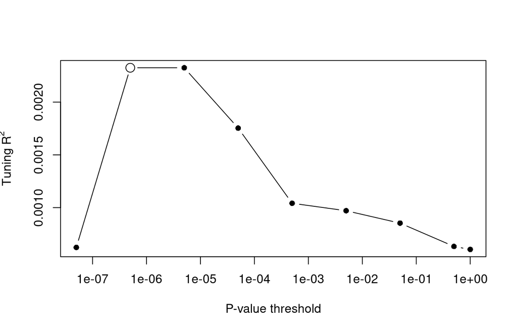

```r
plot(tuning_results$p_threshold, tuning_results$tuning_r_squared,
     log = "x", type = "b", pch = 16,
     xlab = "P-value threshold", ylab = expression(Tuning~R^2))
points(selected_threshold$p_threshold, selected_threshold$tuning_r_squared,
       pch = 21, bg = "white", cex = 1.6)
```

### 5.5 Evaluate the selected score in the validation samples

Evaluate the association between the selected score and the outcome using $R^2$ from `lm(y ~ score)` fitted within the validation samples. The threshold and variant weights are fixed before this step, but the regression intercept and slope are estimated in the validation samples. Thus this is not a measure of calibration or prediction error for an outcome model fitted entirely in the tuning samples.

```r
selected_scores <- prs_align_scores(
  file.path(run_dir, paste0("prs_", best_index, ".sscore")), outcome, target_fam
)
validation <- selected_scores[subset == "validation"]
if (var(validation$score) == 0) {
  stop("The selected score is constant in the validation samples; R-squared is undefined.")
}
validation_model <- lm(y ~ score, data = validation)
validation_results <- data.table(
  selected_p_threshold = p_thresholds[best_index],
  tuning_n = sum(outcome$subset == "tuning"),
  validation_n = nrow(validation),
  tuning_r_squared = selected_threshold$tuning_r_squared,
  validation_r_squared = summary(validation_model)$r.squared
)
fwrite(validation_results, file.path(run_dir, "prs_validation_results.tsv"), sep = "\t")
saveRDS(validation_model, file.path(run_dir, "prs_validation_model.rds"))
knitr::kable(validation_results, digits = 5)
```

| selected_p_threshold | tuning_n | validation_n | tuning_r_squared | validation_r_squared |
| --- | --- | --- | --- | --- |
| 0 | 10000 | 10000 | 0.00233 | 0.0013 |

**Interpretation.** Compare the tuning and validation estimates. A larger tuning $R^2$ may reflect selection among thresholds. These results describe this simulated chromosome 22 exercise; they do not establish genome-wide predictive performance or transferability to another population.

## 6 Analysis record

|  | section | status |
| --- | --- | --- |
| gcta | gcta | completed |
| ldsc | ldsc | completed |
| sldsc | sldsc | completed |
| prs | prs | completed |

```
## Results directory: /vf/users/wongs6/statgen_workshop_2026/heritability-prs/results/run-20260929-133802-38aae1209f79aa
```

[session information not shown]